# STAT240 DIS343 Group 2 Project Draft

Diya

2025-04-12

#### Group Members: Diya Kothari, Max Yefimov, Cindy Wu, Peian Zang

# Introduction

GDP per capita is often used as a measure of a country’s economic prosperity and growth. It can also hint at broader patterns in demographic trends. One such trend is population growth, which is influenced by a variety of economic and social factors.

In this project, we aim to explore the relationship between a country’s GDP and its population growth rate. The main question we will be answering is: Does average GDP per capita influence a country’s average population growth rate from 2000-2019? We chose this question because it’s compelling to examine how economic well-being might affect how the population grows. This ties into debates about whether higher wealth leads to lower birth rates (as seen in developed countries) or enables higher growth (through better healthcare and living conditions), although we do not aim to answer these in our project. After filtering we utilized only countries that were officially recognized by the World Bank, found on their website, to ensure consistency with the data we were using, however we did no further distinctions between their economic statuses.

We find no strong evidence that average GDP per capita is linearly associated with average population growth rate between 2000 and 2019. Our analysis reveals a more complex relationship that goes against a simple linear relationship, suggesting that economic development’s impact on demographics follows nuanced systems that vary across different economic development stages.

# Background

### Data Source

- Raw data: The datasets used in this analysis are collected by DataHub and sourced from the World Bank. The World Bank compiles data collected from various international sources, including, but not limited to, the World Bank national accounts data and OECD National Accounts data files.
- Data Links: [GDP per Country](https://datahub.io/core/gdp) / [Population per Country](https://datahub.io/core/population)

### Variables

- **Country**: The name of the country the data refers to
- **Average GDP per capita**: A country’s gross domestic product divided by its population for a given year, measured in current U.S. dollars. It’s a widely used indicator to assess a country’s standard of living and economic well-being. For this analysis, we calculate the average GDP per capita for each country across the years 2000 to 2019.
- **Average Population Growth**: The average annual percentage change in a country’s population from 2000 to 2019. It reflects the rate at which a country’s population has grown over time. This variable captures factors such as birth rates, death rates, and migration.

### Residual Graph

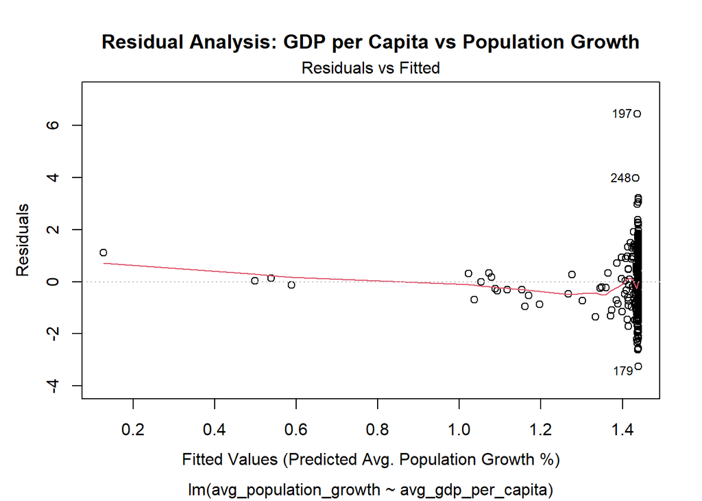

The residuals vs. fitted values plot shows that the differences between the predicted and actual population growth values increase as the predicted values get higher. It is used to assess whether the assumptions of linear regression are met. Specifically, it helps evaluate the following three assumptions:

- **Linearity**: The relationship between the independent variable (average GDP per capita) and the dependent variable (average population growth) should be linear. The curve in the red LOESS line suggests the relationship is **not linear**. The non-linearity suggests that population growth may respond differently to GDP changes at different economic development stages.
- **Normality of Residuals**: The residuals should be normally distributed. Since the fitted values are heavily compressed around one end (1.4), the normality assumption is **violated**. This suggests that the specificity of our predictions is off, particularly for countries at economic extremes.
- **Homoscedasticity (constant variance)**: The residuals should have a consistent spread across all fitted values. However, the spread of residuals as fitted values is increasing (funnel-shape) which indicates heteroscedasticity, meaning the variance is not constant and this assumption is **violated**. This suggests that population growth becomes more variable and less predictable at higher growth rates, possibly reflecting greater economic instability in rapidly growing populations.

# Statistical Analysis

In this study, we are investigating the relationship between a country’s average GDP per capita and its average population growth rate. We use a two-sided hypothesis test because while existing literature and theory suggest that economic prosperity may influence population growth—either positively through improved living conditions or negatively through lower birth rates—the direction of this effect is not definitively established.

### Parameters of Interest

The parameters of interest in this analysis are the true linear relationship between a country’s economic prosperity (measured by GDP per capita) and its population growth rate from 2000–2019:

- $\beta_1$ : The true slope of the linear regression line predicting average population growth from average GDP per capita.
- $\beta_0$ : The true intercept of the regression line.

### Type of Inference

We use **simple linear regression** to estimate the relationship between two quantitative variables:

- **Explanatory variable**: Average GDP per capita
- **Response variable**: Average population growth rate

This form of inference allows us to determine whether changes in GDP per capita are significantly associated with changes in population growth.

### Assumptions

- **X** = Average GDP per Capita (2000–2019)
- **Y** = Average Population Growth Rate (2000–2019)
- **Linearity**: The relationship between GDP per capita and population growth is approximately linear.
- **Independence**: Each observation (country) is independent of the others. This is reasonable, as each row in the dataset represents a distinct country.

### Hypotheses

The hypotheses for this analysis are:

- **Null hypothesis($H_0$)**: $\beta_1$ = 0 - There is no linear relationship between GDP per capita and population growth.
- **Alternative hypothesis($H_1$)**: $\beta_1$ $\neq$ 0 - There is a statistically significant linear relationship between GDP per capita and population growth.

A **two-sided hypothesis test** is used because we are testing for the presence of a relationship, regardless of direction.

A **p-value** is calculated for the slope coefficient to test this hypothesis, and a **95% confidence interval** is reported for β₁ to estimate the range of plausible values for the true effect.

### Test Statistic and Null Distribution

The test statistic is calculated as: $t = \frac{\hat{\beta}_1 - 0}{SE(\hat{\beta}_1)}$

Where:

- $\hat{\beta}_1$: The estimated slope of the regression line (i.e., the change in average population growth rate for a one-unit increase in GDP per capita)
- ${SE(\hat{\beta}_1)}$: The standard error of the slope

The null distribution of the test statistic follows a **t-distribution with (n - 2) degrees of freedom**, where n is the number of countries in the dataset.

### Results

- **Test Statistic (t)**: -1.376997
- **Degrees of Freedom (df)**: 212
- **P-value: 0.1701**

### Interpretation: Compare p-value with $\alpha = 0.05$

We fail to reject the null hypothesis: there is insufficient evidence to suggest a statistically significant linear relationship between average GDP per capita and average population growth rate across countries. (p-value = 0.1701, two-sided test)

### Confidence Interval

**95% Confidence Interval**: -1.381066e-05, 2.452676e-06

The 95% confidence interval for the slope coefficient ranges from approximately **-1.38e-05 to 2.45e-06**. Since this interval includes 0, it suggests that the effect of GDP per capita on population growth rate is **not statistically significant** at the 5% level.

This reinforces our conclusion that we do not have sufficient evidence to claim a linear relationship between these two variables across countries from 2000 to 2019.

# Discussion

### a.Further interpretation

Our analysis found no statistically significant linear relationship between a country’s average GDP per capita and its average population growth rate from 2000 to 2019. Since the p-value of 0.1701 is greater than the significance level of 0.05, we fail to reject the null hypothesis.

For non-statistical readers, the p-value tells us the likelihood of seeing our data (or something more extreme) if there truly were no relationship between GDP per capita and population growth. A large p-value, like the one we observed, suggests that such a relationship is likely due to random variation rather than a true underlying effect.

The 95% confidence interval for the slope of the regression line is [-1.38e-05, 2.45e-06], which includes zero. This further reinforces our conclusion that there’s no strong evidence of a meaningful linear association between these two variables on a global scale during the specified period.

The implications of our finding show that GDP and economic factors should not be used by politicians as a singular solution to problems within a country, where many candidates tend to run on a primarily economic platform, it is important to be skeptical as to how much of the country can be explained by its economic performance.

### c.Additional Questions and Recommendations for Future Research

- **Nonlinear Modeling**: If the effect of GDP on population growth changes at different income levels, nonlinear models may better capture the relationship. This question would personalize the relationship between the two variables to different stages of a country’s evolution in the global economic system, showing differences between countries similar to each other.
- **Regional Analysis**: Future analysis could involve analyzing regional trends, separating countries into different income groups to see if different patterns emerge. Regional economies tend to feature similar economic makeup so by focusing a question on specific regions it could allow for an understanding if the relationship is more prevalent in some parts of the world rather than others.
- **Consider Alternative Economic Measures**: Future analysis could use GDP adjusted for PPP. This adjustment could help reduce distortions caused by currency exchange rates and provide a more fair comparison of how much people in each country can actually afford. This type of question would standardize the comparisons and possibly provide more clarity as to the specific differences between different countries.
- **Include more variables**: A multiple regression model that includes other variables - such as education levels and healthcare access - might provide a clearer picture of what drives population growth. These variables tend to be indicators of quality of life the higher they are for a respective country, so relationships could be identified between countries that have a high quality of life and how their population growth and economic growth change from that